# Harmful Storm Events - Highlighting Harmful Events to Health and Economy

Michael Volk

May 26, 2020

## Synopsis

Using data published by the NOASS Storm Database over 2019 and 2020 we attempt to highlight the most dangerous storm types in terms of both human health and damage. As weather patterns are seasonal we highlight changes across different seasons to allow for proper seasonal planning.

## Questions

### Question 1:

Across the United States, which types of events are most harmful with respect to population health?

### Question 2:

Across the United States, which types of events have the greatest economic consequences?

## Data Processing

Necessary packages

```r
library(tidyverse)
library(lubridate)
library(forcats)
library(scales)
library(gridExtra)
```

OS information

R.Version()[c(“platform”, “version.string”)]

```r
R.Version()[c("platform", "version.string")]
```

```
## $platform
## [1] "x86_64-w64-mingw32"
##
## $version.string
## [1] "R version 3.6.2 (2019-12-12)"
```

Read in data

```r
df <- read.csv("repdata_data_StormData.csv.bz2")
```

Table processing for figures

We know that storms are seasonal, so we look to find if there are is a particular type of storm responsible for the most fatalities or injuries during a specific month.

```r
most_health <- df %>% group_by(EVTYPE) %>%
      summarize(fatalities_injuries = sum(FATALITIES) + sum(INJURIES)) %>%
      arrange(desc(fatalities_injuries))
knitr::kable(head(most_health, n = 5), caption = "Table 3.1: Combined Fatality and Injury Totals")
```

Table 3.1: Combined Fatality and Injury Totals

| EVTYPE | fatalities_injuries |
| --- | --- |
| TORNADO | 96979 |
| EXCESSIVE HEAT | 8428 |
| TSTM WIND | 7461 |
| FLOOD | 7259 |
| LIGHTNING | 6046 |

```r
most_damage <- df %>% group_by(EVTYPE) %>%
      summarize(crop_prop = sum(CROPDMG) + sum(PROPDMG)) %>%
      arrange(desc(crop_prop))
knitr::kable(head(most_damage, n = 5), caption = "Table 3.2: Combined Crop and Property Damage Totals")
```

Table 3.2: Combined Crop and Property Damage Totals

| EVTYPE | crop_prop |
| --- | --- |
| TORNADO | 3312277 |
| FLASH FLOOD | 1599325 |
| TSTM WIND | 1445168 |
| HAIL | 1268290 |
| FLOOD | 1067976 |

```r
health_months <- df %>% mutate(MONTHS = fct_explicit_na(months(as.Date(df$BGN_DATE, "%m/%d/%y")))) %>%
    group_by(EVTYPE, MONTHS) %>%
    summarize(fatalities.sum = sum(FATALITIES), injuries.sum = sum(INJURIES)) %>%
      arrange(desc(fatalities.sum + injuries.sum))
knitr::kable(head(health_months, n=10), caption = "Table 1: Storm Events and Health Risk by Month")
```

Table 1: Storm Events and Health Risk by Month

| EVTYPE | MONTHS | fatalities.sum | injuries.sum |
| --- | --- | --- | --- |
| TORNADO | April | 1793 | 29439 |
| TORNADO | May | 1253 | 17003 |
| TORNADO | June | 565 | 9868 |
| TORNADO | March | 662 | 9559 |
| TORNADO | February | 431 | 5688 |
| FLOOD | October | 40 | 6038 |
| EXCESSIVE HEAT | July | 1170 | 4321 |
| TORNADO | November | 251 | 4946 |
| TORNADO | December | 154 | 2928 |
| TORNADO | August | 121 | 2804 |

We also look to see if there is a particular storm type responsible for the economic damage. We again group these by month to see if there are any seasonal trends.

```r
damage_months <- df %>% mutate(MONTHS = fct_explicit_na(months(as.Date(df$BGN_DATE, "%m/%d/%y")))) %>%
      group_by(EVTYPE, MONTHS) %>%
      summarize(crop.damage = sum(CROPDMG), property.damage = sum(PROPDMG)) %>%
      arrange(desc(crop.damage + property.damage))
knitr::kable(head(damage_months, n=10), caption = "Table 2: Storm Events and Economic Damage by Month")
```

Table 2: Storm Events and Economic Damage by Month

| EVTYPE | MONTHS | crop.damage | property.damage |
| --- | --- | --- | --- |
| TORNADO | April | 23266.70 | 591686.6 |
| TORNADO | May | 18008.25 | 579381.0 |
| TORNADO | June | 18288.50 | 435351.3 |
| HAIL | June | 216717.05 | 130218.5 |
| TORNADO | March | 3546.13 | 307695.8 |
| FLASH FLOOD | June | 34341.89 | 255172.8 |
| TSTM WIND | June | 35801.30 | 251244.1 |
| TSTM WIND | July | 23358.60 | 252817.3 |
| HAIL | May | 112601.42 | 156643.7 |
| FLASH FLOOD | May | 47520.67 | 218797.7 |

## Results

### Totals of Health Risks and Damages

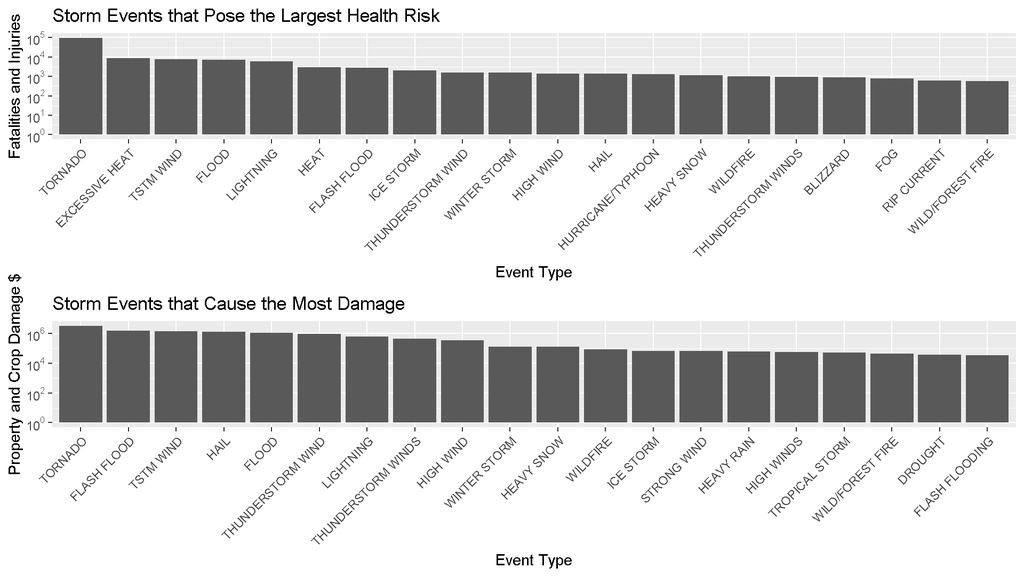

Figure 1

```r
top <- 20
most_health_sm <-  most_health[1:top,]
most_health_sm$EVTYPE <- factor(most_health_sm$EVTYPE, levels = most_health_sm$EVTYPE)

g3_1 <- most_health_sm %>% ggplot(aes(x=EVTYPE, y=fatalities_injuries)) +
      geom_bar(stat = "identity") +
      theme(axis.text.x = element_text(angle = 45, hjust = 1)) +
      scale_y_log10("Fatalities and Injuries",
              breaks = trans_breaks("log10", function(x) 10^x),
              labels = trans_format("log10", math_format(10^.x))) +
      labs(title = "Storm Events that Pose the Largest Health Risk",
           x = "Event Type")

most_damage_sm <-  most_damage[1:top,]
most_damage_sm$EVTYPE <- factor(most_damage_sm$EVTYPE, levels = most_damage_sm$EVTYPE)

g3_2 <- most_damage_sm %>% ggplot(aes(x=EVTYPE, y=crop_prop)) +
      geom_bar(stat = "identity") +
      theme(axis.text.x = element_text(angle = 45, hjust = 1)) +
      scale_y_log10("Property and Crop Damage $",
              breaks = trans_breaks("log10", function(x) 10^x),
              labels = trans_format("log10", math_format(10^.x))) +
      labs(x = "Event Type",
           title = "Storm Events that Cause the Most Damage")

grid.arrange(g3_1,g3_2,nrow=2)
```

### Question 1

We plot storm fatalities and injuries by storm type and color categorized by month to pick out major trends.

[figure not shown]

Figure 2

```r
percent <- 4
health_months_gat <- health_months %>% ungroup() %>%
      mutate(ID = row_number(EVTYPE)) %>%
      gather(key = health_risk, value = totals, fatalities.sum:injuries.sum)
n_obs_health <-floor(dim(health_months_gat)[[1]] * percent/100)
health_months_gat <- health_months_gat %>% arrange(desc(totals))
health_months_gat$health_risk <- factor(health_months_gat$health_risk)
health_months_gat_sm <- health_months_gat[1:n_obs_health,]
# Correcting Factors for cleaner plot
health_months_gat_sm$MONTHS <- fct_explicit_na(factor(health_months_gat_sm$MONTHS, levels = month.name))

Title <- paste(paste0((sprintf("The Top %s",percent)), "%"), "by Total of Storm Event Injuries/Fatalities")
g1 <- ggplot(health_months_gat_sm, aes(EVTYPE, totals)) +
      geom_point(aes(color = MONTHS), size = 4, alpha = 0.3) +
      theme(axis.text.x = element_text(angle = 45, hjust=1), plot.title = element_text(hjust = 0.5)) +
      scale_y_continuous(trans = "log10") +
      labs(title = Title, x = "Event Type", y = expression(Total~Dollars~(log[10]~scale))) +
      facet_grid(health_risk~.)
g1
```

### Discussion: Figure 2

**TORNADOS**

TORNADOS pose the largest threat to health as they account for the largest number of both deaths and fatalities. Most of the deaths/fatalities from TORNADOS occur during Spring months, namely March, April, and May.

**FLOODS**

**EXCESSIVE HEAT**

EXCESSIVE HEAT pose a large threat to health. As expected, most of the deaths/fatalties from EXCESSIVE HEAT takes place during Summer months, namely June, July, and August.

### Question 2

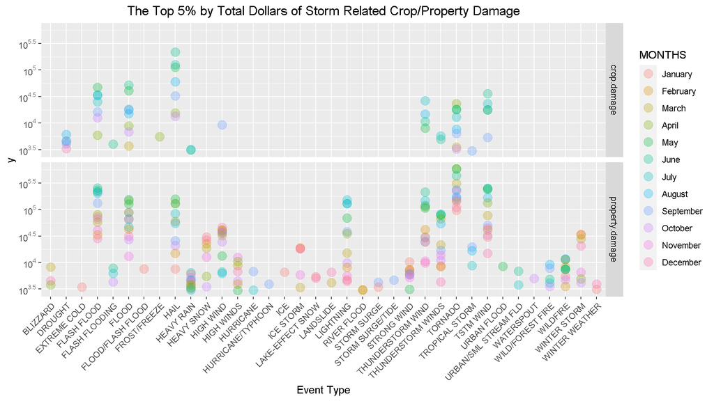

Figure 3

```r
percent <- 5
damage_months_gat <- damage_months %>% ungroup() %>%
      mutate(ID = row_number(EVTYPE)) %>%
      gather(key = economic_damage, value = totals, crop.damage:property.damage)
n_obs_damage <-floor(dim(damage_months_gat)[[1]] * percent/100)
damage_months_gat <- damage_months_gat %>% arrange(desc(totals))
damage_months_gat$health_risk <- factor(damage_months_gat$economic_damage)
damage_months_gat_sm <- damage_months_gat[1:n_obs_damage,]
# Correcting Factors for cleaner plot
damage_months_gat_sm$MONTHS <- fct_explicit_na(factor(damage_months_gat_sm$MONTHS, levels = month.name))

Title <- paste(paste0((sprintf("The Top %s",percent)), "%"), "by Total Dollars of Storm Related Crop/Property Damage")
g2 <- ggplot(damage_months_gat_sm, aes(EVTYPE, totals)) +
      geom_point(aes(color = MONTHS), size = 4, alpha = 0.3) +
      theme(axis.text.x = element_text(angle = 45, hjust=1), plot.title = element_text(hjust = 0.5)) +
      scale_y_log10("y",
                    breaks = trans_breaks("log10", function(x) 10^x),
                    labels = trans_format("log10", math_format(10^.x))) +
      labs(title = Title, x = "Event Type", y = expression(Total~Dollars~(log[10]~scale))) +
      facet_grid(economic_damage~.)
g2
```

### Discussion: Figure 3

**TORNDADOS**

As we might expect from Figure 1 the damage caused by TORNADOS is substantial. TORNADOS cause the most combined property damage and crop damage for any given month.

**HAIL**

HAIL Causes a great deal of crop damage, and most of this damage occurs during the Summer months. In fact the most amount of crop damage occurs in June from HAIL.